# Data624 - Project2

Group 2

November 13, 2017

# Overview

### Abstract

The purpose of this report is to address the new regulations and to better understand the manufacturing process within ABC Beverage. We will examine all factors involved in the production process and will attempt to identify the factors that will help us properly predict the PH levels as well us understand the influence of the various factors on the overall process.

### Data used

This report is using the historical data collected from approximately 2572 samples which should be sufficient for the analysis.

### Brief overview of the process

We will first cleanup the data, by filling in or imputing the missing data, use various transformation methods in order to normalize the data to address issues such as outlier data points and other normalization related issues.

Next we will run various models in order to identify the factors that are important to reaching out goal and once we have those we will use various models in order to estimate the PH levels and come up with a best suiting method that we feel will be best to predict the data we are looking for.

We will include documented R code within the report so that it is easy to follow our research. Should you have any questions regarding the process or the code, feel free to reach out to our department.

# Data Exploration

We will get started by loading our historical data into a data frame and loading the necessary libraries.

```r
library(missForest)
library(corrgram)
library(caret)
library(psych)
library(knitr)

dfBevMod <- read.csv("https://github.com/ChristopheHunt/CUNY-DATA624/raw/master/data/StudentData.csv", header = TRUE)
dfBevPred <- read.csv("https://raw.githubusercontent.com/ChristopheHunt/CUNY-DATA624/master/data/StudentEvaluation-%20TO%20PREDICT.csv", header =TRUE)
```

We will examine the training dataset we want to see how many predictor variables we are dealing with and if we are missing any data. We see several variables with missing data,

```r
dim(dfBevMod)
```

```
## [1] 2571   33
```

It appears we have a total of 32 predictor variables and a target variable. Next we will check for any missing data.

```r
colSums(is.na(dfBevMod))
```

```
##        Brand.Code       Carb.Volume       Fill.Ounces         PC.Volume
##                 0                10                38                39
##     Carb.Pressure         Carb.Temp               PSC          PSC.Fill
##                27                26                33                23
##           PSC.CO2          Mnf.Flow    Carb.Pressure1     Fill.Pressure
##                39                 2                32                22
##     Hyd.Pressure1     Hyd.Pressure2     Hyd.Pressure3     Hyd.Pressure4
##                11                15                15                30
##      Filler.Level      Filler.Speed       Temperature        Usage.cont
##                20                57                14                 5
##         Carb.Flow           Density               MFR           Balling
##                 2                 1               212                 1
##   Pressure.Vacuum                PH     Oxygen.Filler     Bowl.Setpoint
##                 0                 4                12                 2
## Pressure.Setpoint     Air.Pressurer          Alch.Rel          Carb.Rel
##                12                 0                 9                10
##       Balling.Lvl
##                 1
```

We see many variables with NA’s – notably “MFR” has 212. Still, roughly 8% NA is workable, so we’ll choose to use imputation process to fill in the missing data.

Also, it appears that we have one categorical variable: Brand.Code

### Barchart

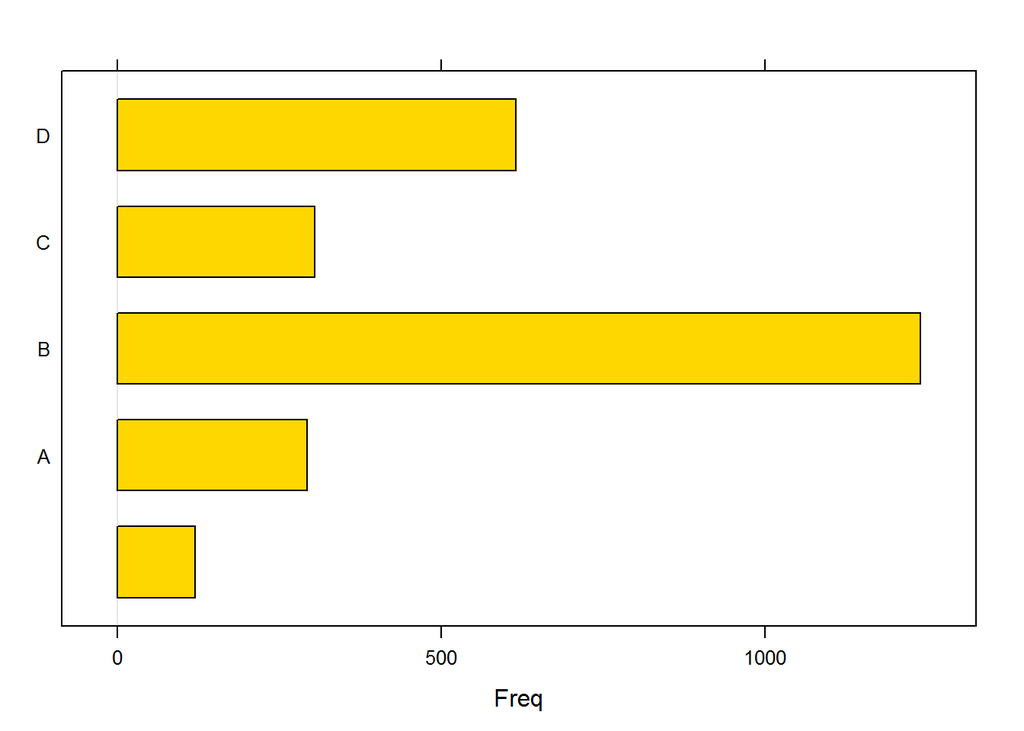

```r
#Visualizing the single categorical variable
barchart(dfBevMod[,1], col="Gold")
```

It appears that brand “B” occurs most frequently, followed by “D”

### Continuous and Discrete variables

Next we will review all the variables we are working with in order to better understand the data they are presenting us. We can see the mean, variation and other metrics within the following table for a quick detailed reference.

```r
library(psych)
library(knitr)
table.desc <- describe(dfBevMod[,-1])
table.prep <- as.matrix(table.desc)
table.round <- round((table.prep), 2)
kable(table.round)
```

|  | vars | n | mean | sd | median | trimmed | mad | min | max | range | skew | kurtosis | se |
| --- | --- | --- | --- | --- | --- | --- | --- | --- | --- | --- | --- | --- | --- |
| Carb.Volume | 1 | 2561 | 5.37 | 0.11 | 5.35 | 5.37 | 0.11 | 5.04 | 5.70 | 0.66 | 0.39 | -0.47 | 0.00 |
| Fill.Ounces | 2 | 2533 | 23.97 | 0.09 | 23.97 | 23.98 | 0.08 | 23.63 | 24.32 | 0.69 | -0.02 | 0.86 | 0.00 |
| PC.Volume | 3 | 2532 | 0.28 | 0.06 | 0.27 | 0.27 | 0.05 | 0.08 | 0.48 | 0.40 | 0.34 | 0.67 | 0.00 |
| Carb.Pressure | 4 | 2544 | 68.19 | 3.54 | 68.20 | 68.12 | 3.56 | 57.00 | 79.40 | 22.40 | 0.18 | -0.01 | 0.07 |
| Carb.Temp | 5 | 2545 | 141.09 | 4.04 | 140.80 | 140.99 | 3.85 | 128.60 | 154.00 | 25.40 | 0.25 | 0.24 | 0.08 |
| PSC | 6 | 2538 | 0.08 | 0.05 | 0.08 | 0.08 | 0.05 | 0.00 | 0.27 | 0.27 | 0.85 | 0.65 | 0.00 |
| PSC.Fill | 7 | 2548 | 0.20 | 0.12 | 0.18 | 0.18 | 0.12 | 0.00 | 0.62 | 0.62 | 0.93 | 0.77 | 0.00 |
| PSC.CO2 | 8 | 2532 | 0.06 | 0.04 | 0.04 | 0.05 | 0.03 | 0.00 | 0.24 | 0.24 | 1.73 | 3.73 | 0.00 |
| Mnf.Flow | 9 | 2569 | 24.57 | 119.48 | 65.20 | 21.07 | 169.02 | -100.20 | 229.40 | 329.60 | 0.00 | -1.87 | 2.36 |
| Carb.Pressure1 | 10 | 2539 | 122.59 | 4.74 | 123.20 | 122.54 | 4.45 | 105.60 | 140.20 | 34.60 | 0.05 | 0.14 | 0.09 |
| Fill.Pressure | 11 | 2549 | 47.92 | 3.18 | 46.40 | 47.71 | 2.37 | 34.60 | 60.40 | 25.80 | 0.55 | 1.41 | 0.06 |
| Hyd.Pressure1 | 12 | 2560 | 12.44 | 12.43 | 11.40 | 10.84 | 16.90 | -0.80 | 58.00 | 58.80 | 0.78 | -0.14 | 0.25 |
| Hyd.Pressure2 | 13 | 2556 | 20.96 | 16.39 | 28.60 | 21.05 | 13.34 | 0.00 | 59.40 | 59.40 | -0.30 | -1.56 | 0.32 |
| Hyd.Pressure3 | 14 | 2556 | 20.46 | 15.98 | 27.60 | 20.51 | 13.94 | -1.20 | 50.00 | 51.20 | -0.32 | -1.57 | 0.32 |
| Hyd.Pressure4 | 15 | 2541 | 96.29 | 13.12 | 96.00 | 95.45 | 11.86 | 52.00 | 142.00 | 90.00 | 0.55 | 0.63 | 0.26 |
| Filler.Level | 16 | 2551 | 109.25 | 15.70 | 118.40 | 111.04 | 9.19 | 55.80 | 161.20 | 105.40 | -0.85 | 0.05 | 0.31 |
| Filler.Speed | 17 | 2514 | 3687.20 | 770.82 | 3982.00 | 3919.99 | 47.44 | 998.00 | 4030.00 | 3032.00 | -2.87 | 6.71 | 15.37 |
| Temperature | 18 | 2557 | 65.97 | 1.38 | 65.60 | 65.80 | 0.89 | 63.60 | 76.20 | 12.60 | 2.39 | 10.16 | 0.03 |
| Usage.cont | 19 | 2566 | 20.99 | 2.98 | 21.79 | 21.25 | 3.19 | 12.08 | 25.90 | 13.82 | -0.54 | -1.02 | 0.06 |
| Carb.Flow | 20 | 2569 | 2468.35 | 1073.70 | 3028.00 | 2601.14 | 326.17 | 26.00 | 5104.00 | 5078.00 | -0.99 | -0.58 | 21.18 |
| Density | 21 | 2570 | 1.17 | 0.38 | 0.98 | 1.15 | 0.15 | 0.24 | 1.92 | 1.68 | 0.53 | -1.20 | 0.01 |
| MFR | 22 | 2359 | 704.05 | 73.90 | 724.00 | 718.16 | 15.42 | 31.40 | 868.60 | 837.20 | -5.09 | 30.46 | 1.52 |
| Balling | 23 | 2570 | 2.20 | 0.93 | 1.65 | 2.13 | 0.37 | -0.17 | 4.01 | 4.18 | 0.59 | -1.39 | 0.02 |
| Pressure.Vacuum | 24 | 2571 | -5.22 | 0.57 | -5.40 | -5.25 | 0.59 | -6.60 | -3.60 | 3.00 | 0.53 | -0.03 | 0.01 |
| PH | 25 | 2567 | 8.55 | 0.17 | 8.54 | 8.55 | 0.18 | 7.88 | 9.36 | 1.48 | -0.29 | 0.06 | 0.00 |
| Oxygen.Filler | 26 | 2559 | 0.05 | 0.05 | 0.03 | 0.04 | 0.02 | 0.00 | 0.40 | 0.40 | 2.66 | 11.09 | 0.00 |
| Bowl.Setpoint | 27 | 2569 | 109.33 | 15.30 | 120.00 | 111.35 | 0.00 | 70.00 | 140.00 | 70.00 | -0.97 | -0.06 | 0.30 |
| Pressure.Setpoint | 28 | 2559 | 47.62 | 2.04 | 46.00 | 47.60 | 0.00 | 44.00 | 52.00 | 8.00 | 0.20 | -1.60 | 0.04 |
| Air.Pressurer | 29 | 2571 | 142.83 | 1.21 | 142.60 | 142.58 | 0.59 | 140.80 | 148.20 | 7.40 | 2.25 | 4.73 | 0.02 |
| Alch.Rel | 30 | 2562 | 6.90 | 0.51 | 6.56 | 6.84 | 0.06 | 5.28 | 8.62 | 3.34 | 0.88 | -0.85 | 0.01 |
| Carb.Rel | 31 | 2561 | 5.44 | 0.13 | 5.40 | 5.43 | 0.12 | 4.96 | 6.06 | 1.10 | 0.50 | -0.29 | 0.00 |
| Balling.Lvl | 32 | 2570 | 2.05 | 0.87 | 1.48 | 1.98 | 0.21 | 0.00 | 3.66 | 3.66 | 0.59 | -1.49 | 0.02 |

### Nominal Variable Histogram

Next we will visually view each one of the factors, its easier to visually navigate through a large number of variables. We are interested to see how data is distributed for each one of the variables. Please refer to above table for more specific information.

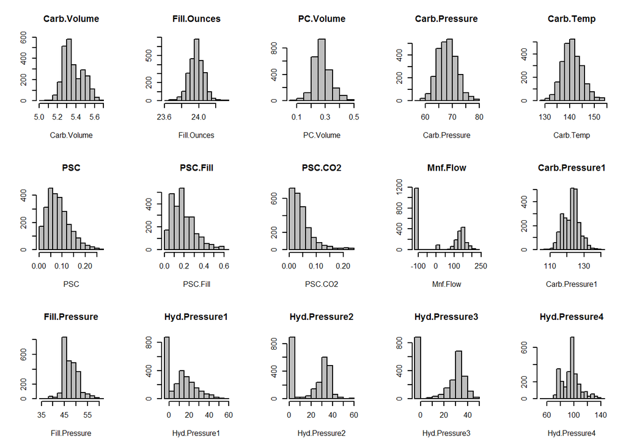

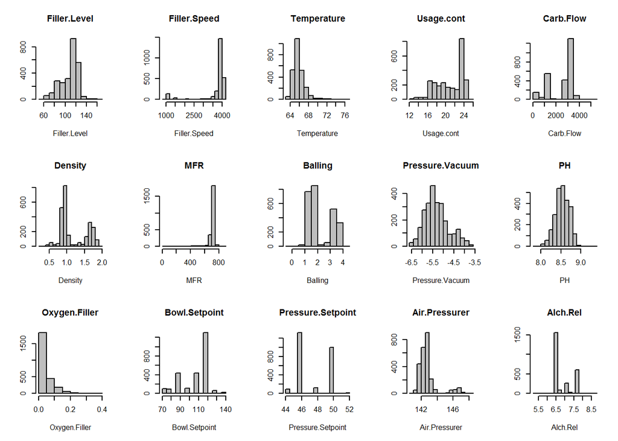

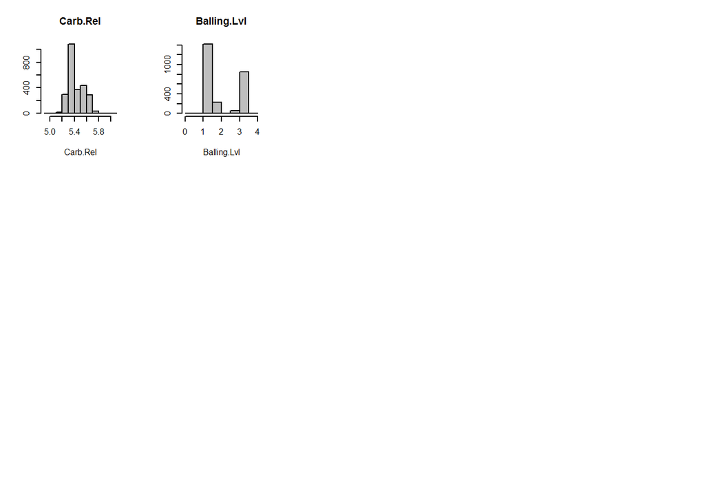

```r
dfBevModH <- dfBevMod[2:ncol(dfBevMod)] #removing factor var
par(mfrow = c(3,5), cex = .5)
for(i in colnames(dfBevModH)){
hist(dfBevModH[,i], xlab = names(dfBevMod[i]),
  main = names(dfBevModH[i]), col="grey", ylab="")
}
```

Next we want to explore differences by Brand

```r
BrandA <- dfBevMod[dfBevMod$Brand.Code == "A",]
BAM <- colMeans(BrandA[,2:ncol(BrandA)], na.rm = TRUE)
BrandB <- dfBevMod[dfBevMod$Brand.Code == "B",]
BBM <- colMeans(BrandB[,2:ncol(BrandB)], na.rm = TRUE)
BrandC <- dfBevMod[dfBevMod$Brand.Code == "C",]
BCM <- colMeans(BrandC[,2:ncol(BrandC)], na.rm = TRUE)
BrandD <- dfBevMod[dfBevMod$Brand.Code == "D",]
BDM <- colMeans(BrandD[,2:ncol(BrandD)], na.rm = TRUE)
BrandE <- dfBevMod[dfBevMod$Brand.Code == "",]
BEM <- colMeans(BrandE[,2:ncol(BrandE)], na.rm = TRUE)

combBrand <- cbind(BAM, BBM, BCM, BDM, BEM)
combBrand
```

```
##                             BAM           BBM           BCM           BDM
## Carb.Volume          5.42568828    5.31248514    5.30019802    5.51044190
## Fill.Ounces         23.98210526   23.97748705   23.98486667   23.95658456
## PC.Volume            0.26877855    0.28239989    0.29019778    0.26174013
## Carb.Pressure       69.28041237   67.19804719   66.92476821   70.69817579
## Carb.Temp          141.22876712  141.11078431  141.05364238  141.13013115
## PSC                  0.07761672    0.08635948    0.08976821    0.08056579
## PSC.Fill             0.19835052    0.19371847    0.21026490    0.19104918
## PSC.CO2              0.05551724    0.05709360    0.06214765    0.05276316
## Mnf.Flow            39.71467577   20.46176233   23.28092105   25.74666667
## Carb.Pressure1     122.81862069  122.47500000  122.19401993  122.72363636
## Fill.Pressure       48.22123288   48.17010561   48.22866667   46.96124795
## Hyd.Pressure1       12.90238908   12.52469636   12.32828947   12.39671053
## Hyd.Pressure2       21.15821918   21.10510949   19.16250000   21.97331137
## Hyd.Pressure3       20.97465753   20.19253852   19.04671053   21.59011532
## Hyd.Pressure4      101.28368794  100.05858421  102.54000000   83.45276873
## Filler.Level       108.62671233  107.96156352  111.60198020  110.42262295
## Filler.Speed      3582.07719298 3730.61943987 3673.66216216 3688.97674419
## Temperature         66.06323024   65.89083536   66.71655629   65.46209150
## Usage.cont          21.14034247   20.96623482   21.03657895   21.00653659
## Carb.Flow         2387.35395189 2532.70056497 2311.53947368 2437.18048780
## Density              1.57105802    0.90843296    0.92217105    1.68250407
## MFR                704.98365759  705.63864818  704.02826087  703.97628319
## Balling              3.19896928    1.51114216    1.63171053    3.48558699
## Pressure.Vacuum     -5.23890785   -5.15431800   -5.31052632   -5.26016260
## PH                   8.49740614    8.56678543    8.41368421    8.60250407
## Oxygen.Filler        0.04147423    0.04783906    0.05160930    0.04495863
## Bowl.Setpoint      109.11340206  107.76432607  111.61842105  110.88780488
## Pressure.Setpoint   47.76219931   47.94269572   48.03367003   46.64600326
## Air.Pressurer      142.73583618  142.95948345  142.76644737  142.69300813
## Alch.Rel             7.13486301    6.55051095    6.56488449    7.69352846
## Carb.Rel             5.51773973    5.36215385    5.35242525    5.60725203
## Balling.Lvl          3.07706485    1.40611784    1.52059211    3.23206504
##                             BEM
## Carb.Volume          5.29086111
## Fill.Ounces         23.99712644
## PC.Volume            0.28882759
## Carb.Pressure       66.26050420
## Carb.Temp          140.51794872
## PSC                  0.09037607
```

[output cut: 11 more lines]

```
## Temperature         67.22689076
## Usage.cont          20.72933333
## Carb.Flow         2557.43333333
## Density              0.96866667
## MFR                685.10280374
## Balling              1.67083333
## Pressure.Vacuum     -5.33333333
## PH                   8.48883333
## Oxygen.Filler        0.04730084
## Bowl.Setpoint      112.16666667
## Pressure.Setpoint   47.79831933
## Air.Pressurer      142.67166667
## Alch.Rel             6.64151261
## Carb.Rel             5.34423729
## Balling.Lvl          1.46873950
```

Notable differences exist among brands by Hyd.Pressure4, Density, Balling, and Balling.Lvl

### Density Plot

Next we will use density plots to better understand the data and look for any abnormalities.

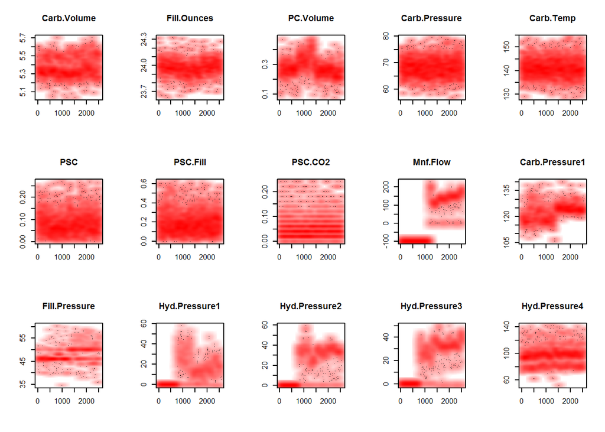

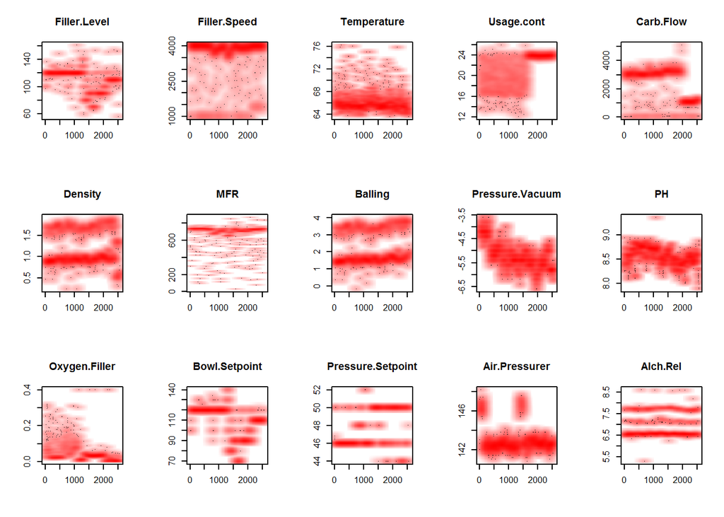

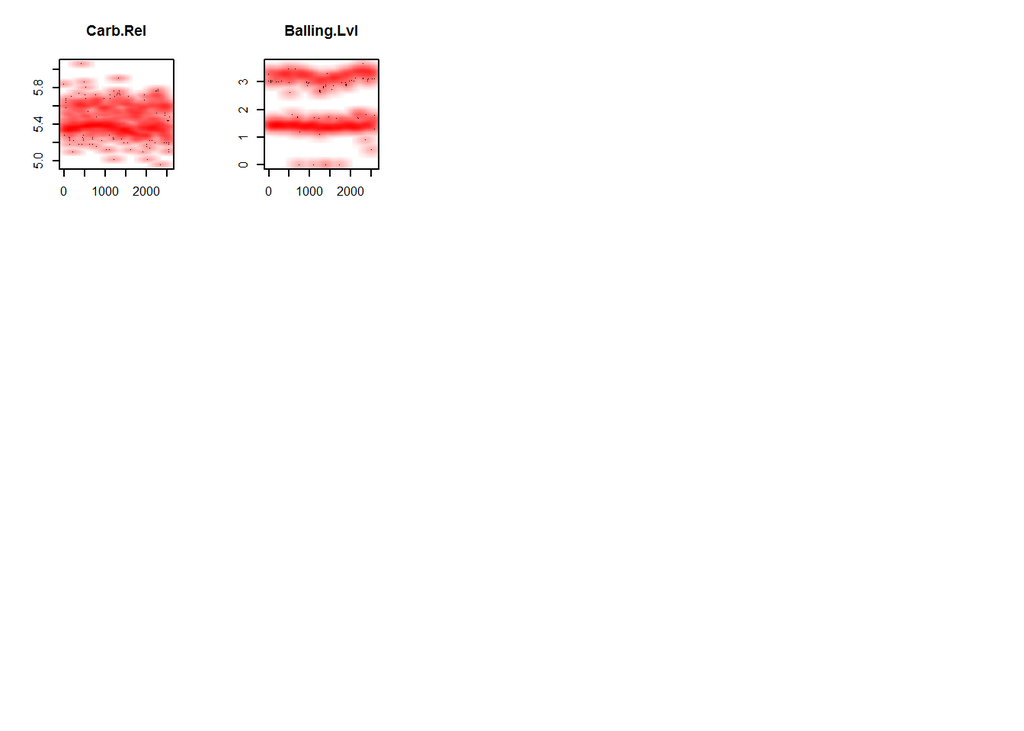

```r
par(mfrow = c(3,5), cex = .5)
for (i in colnames(dfBevModH)) {
 smoothScatter(dfBevModH[,i], main = names(dfBevModH[i]), ylab = "",
   xlab = "", colramp = colorRampPalette(c("white", "red")))
 }
```

The odd data in Mnf.Flow appears to be related to similarly zero-out data in Hyd.Pressure1, Hyd.Press2, and Hyd.Pressure3. Several other variables have dichotomous patterns in data behavior, including “Carb.Pressure1”, “Filler.Level”, “Usage.cont”, “Carb.Flow”, and “Oxygen.Filler”. This leaves two options; we can alter these gaps by possibly inputing new values in, or we can use algorithms that can easily handle quick pattern shifts, such as forests and MARS.

### BoxPlots

Next we want to take a look at any outliers within our variables. Boxplots provide a quick and effective way of view the data and look for any skew or outliers

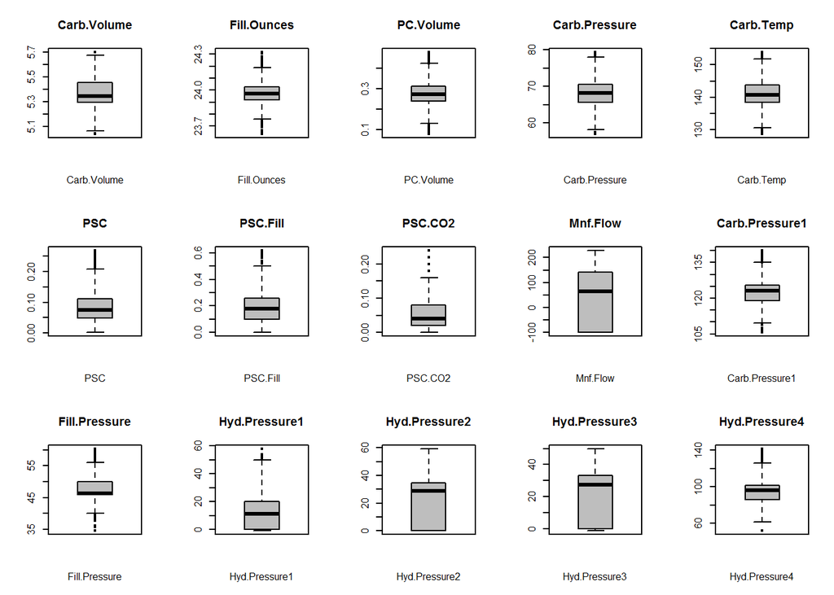

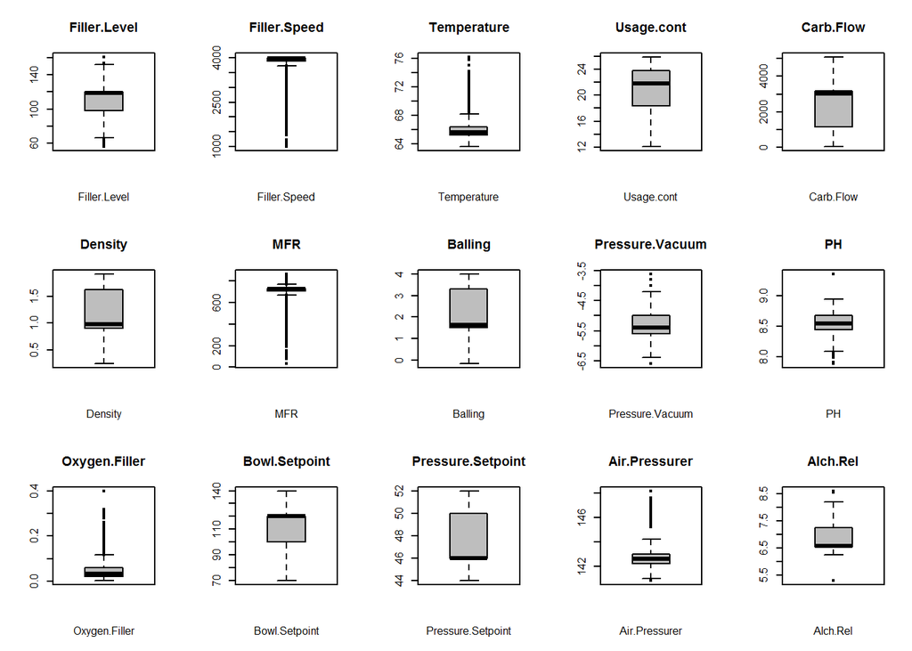

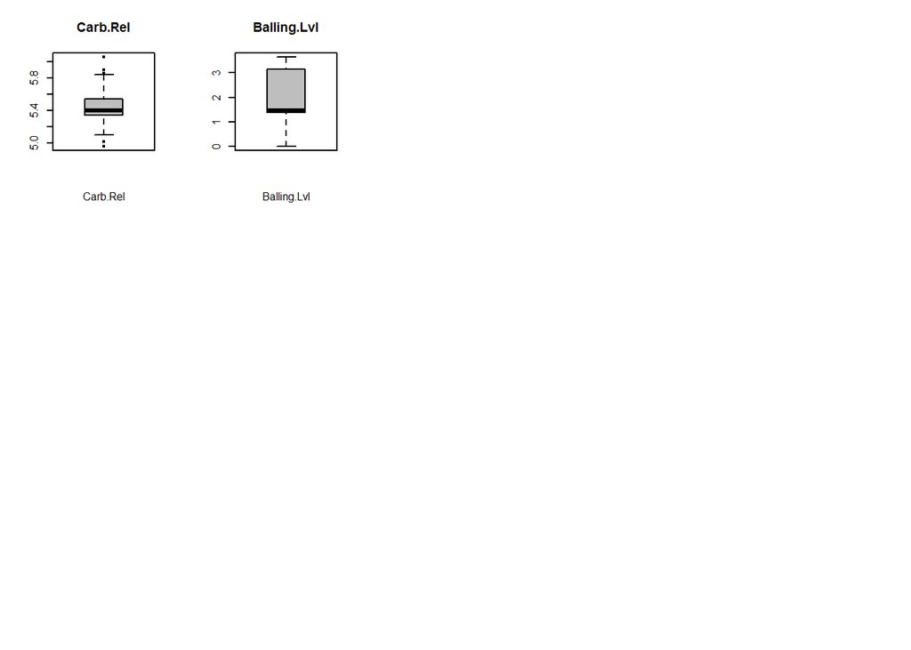

```r
par(mfrow = c(3,5), cex = .5)
for(i in colnames(dfBevModH)){
boxplot(dfBevModH[,i], xlab = names(dfBevModH[i]),
  main = names(dfBevModH[i]), col="grey", ylab="")
}
```

Again, several variables with large skews and outliers are present we will need to use transformation techniques later on to handle this issue.

### Principle Component Analysis

Since we are dealing with 32 predictor variables and not all of them can be relevant to our study, we will need a way to filter through the variables to reduce the number of variables we are working with. This can be done with PCA

```
## $`Importance of Components`
##                             PC1      PC2      PC3     PC4      PC5
## Standard deviation     2.540088 2.449148 1.477634 1.47603 1.310421
## Proportion of Variance 0.201630 0.187450 0.068230 0.06808 0.053660
## Cumulative Proportion  0.201630 0.389070 0.457310 0.52539 0.579050
##
## $`Rotation (Variable Loadings)`
##                            PC1          PC2          PC3           PC4
## Carb.Volume       -0.320871550  0.126525924 -0.063988169  0.0689976465
## Fill.Ounces        0.033313610 -0.010524814  0.073850141  0.2358285280
## PC.Volume          0.072479708 -0.108552900 -0.069562774 -0.3956296184
## Carb.Pressure     -0.208006297  0.060068377 -0.068128144  0.1465200114
## Carb.Temp         -0.033305138 -0.006187462 -0.040764654  0.1184540029
## PSC                0.034729843 -0.007932387  0.007672846  0.0166335686
## PSC.Fill           0.005088232 -0.025583769 -0.008017467  0.0803836356
## PSC.CO2            0.029539988  0.013537129 -0.010869845  0.1017169746
## Mnf.Flow           0.080644367  0.358177152  0.044915507  0.0252965168
## Carb.Pressure1     0.037910196  0.212302734  0.028684308  0.1765112631
## Fill.Pressure      0.162738779  0.217724987 -0.208305845  0.0873750286
## Hyd.Pressure1      0.040714287  0.156202166  0.028117601 -0.4998183585
## Hyd.Pressure2      0.057453860  0.313403614  0.076107892 -0.3208825682
## Hyd.Pressure3      0.071682634  0.348252038  0.032135037 -0.2278539437
## Hyd.Pressure4      0.268513018 -0.023674824 -0.168038357 -0.0027778884
## Filler.Level      -0.098309141 -0.276213319  0.109275148 -0.2476992005
## Filler.Speed      -0.036355308  0.001197480  0.619301867  0.0628275426
## Temperature        0.105282829 -0.066203240 -0.105105120  0.0321416038
## Usage.cont         0.053341657  0.248028048  0.106147980  0.1153232541
## Carb.Flow         -0.019747290 -0.192400631 -0.190052445  0.0123151046
## Density           -0.355713158  0.107013359 -0.067887877 -0.0009745302
## MFR               -0.040893045 -0.001083672  0.620594464  0.0666977237
## Balling           -0.354342525  0.141148693 -0.040775757 -0.0141207975
## Pressure.Vacuum   -0.046505652 -0.268137181  0.018936117  0.2043414157
## PH                -0.115017697 -0.166446153 -0.043839565 -0.1546589220
## Oxygen.Filler     -0.017291886 -0.210617922 -0.096839733 -0.0417513911
## Bowl.Setpoint     -0.103923455 -0.273585690  0.086519475 -0.2471199864
## Pressure.Setpoint  0.181047509  0.208820308 -0.105820469  0.0562644751
## Air.Pressurer      0.031569404 -0.035033996 -0.071242723  0.2609739989
## Alch.Rel          -0.364650212  0.099430202 -0.076928665 -0.0194895814
## Carb.Rel          -0.352557712  0.079691885 -0.073882285 -0.0418290381
## Balling.Lvl       -0.361905544  0.108856318 -0.069790925  0.0073156499
```

[output cut: 86 more lines]

```
## Temperature        0.103770602
## Usage.cont        -0.454543589
## Carb.Flow          0.950568080
## Density            0.034322442
## MFR                0.224469906
## Balling           -0.084814051
## Pressure.Vacuum    0.277242437
## PH                 0.211975600
## Oxygen.Filler      0.354347799
## Bowl.Setpoint      0.012366381
## Pressure.Setpoint -0.169959804
## Air.Pressurer      0.125926876
## Alch.Rel           0.005207278
## Carb.Rel          -0.012596007
## Balling.Lvl       -0.050934875
```

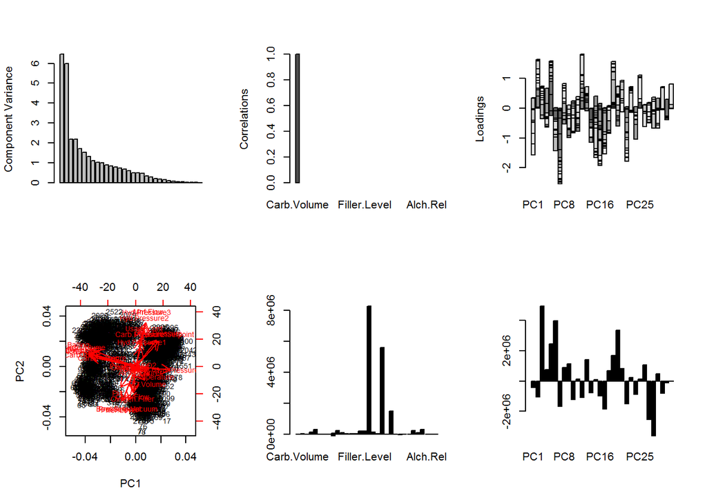

```r
PCA <- function(X) {
  Xpca <- prcomp(na.omit(X), center = T, scale. = T)
  M <- as.matrix(na.omit(X)); R <- as.matrix(Xpca$rotation); score <- M %*% R
  print(list("Importance of Components" = summary(Xpca)$importance[ ,1:5],
             "Rotation (Variable Loadings)" = Xpca$rotation[ ,1:5],
             "Correlation between X and PC" = cor(na.omit(X), score)[ ,1:5]))
  par(mfrow=c(2,3))
  barplot(Xpca$sdev^2, ylab = "Component Variance")
  barplot(cor(cbind(X)), ylab = "Correlations")
  barplot(Xpca$rotation, ylab = "Loadings")
  biplot(Xpca); barplot(M); barplot(score)
}
PCA(dfBevModH)
```

# Data Transformation

Since Brand Code is a categorical variable, we will have to transform it to a binary so that models can use the data.

```r
#df_imputed$Brand.Code = NULL
dfBevMod$Brand.Code[dfBevMod$Brand.Code == ""] <- NA
dfBevMod$Brand.Code <- droplevels(dfBevMod$Brand.Code)

dfBevPred$Brand.Code[dfBevPred$Brand.Code == ""] <- NA
dfBevPred$Brand.Code <- droplevels(dfBevPred$Brand.Code)

#Recode categorical factor
dfBevMod$A <- ifelse(dfBevMod$Brand.Code == "A", 1, 0)
dfBevMod$B <- ifelse(dfBevMod$Brand.Code == "B", 1, 0)
dfBevMod$C <- ifelse(dfBevMod$Brand.Code == "C", 1, 0)
dfBevMod$D <- ifelse(dfBevMod$Brand.Code == "D", 1, 0)
dfBevMod$Brand.Code <- NULL

dfBevPred$A <- ifelse(dfBevPred$Brand.Code == "A", 1, 0)
dfBevPred$B <- ifelse(dfBevPred$Brand.Code == "B", 1, 0)
dfBevPred$C <- ifelse(dfBevPred$Brand.Code == "C", 1, 0)
dfBevPred$D <- ifelse(dfBevPred$Brand.Code == "D", 1, 0)
dfBevPred$Brand.Code <- NULL
```

### Imputation

Next we will use the missForest library to impute the missing variable of the predictor variables. The library will use the best method in filling in the missing data.

Please note: We need to perform this step in order to have a complete dataset. Most models will not run on a data set with missing data. This is a common step in data science and filling in the data does not compromise the final results

```r
#dfImpMod = missForest(dfBevMod)
#dfImpMod$OOBerror #error rate looks good?
#dfModImp <- dfImpMod$ximp

#dfImpPred <- missForest(dfBevPred)
#dfPredImp <- dfImpPred$ximp
#dfPredImp$PH <- NA #redadding PH

#write.csv(dfModImp, "TrainImputeData.csv")
#write.csv(dfPredImp, "PredictImputeData.csv")

#Stored current imputation results on github to quicken knitr iterations
dfModImp <- read.csv("https://raw.githubusercontent.com/ChristopheHunt/CUNY-DATA624/master/data/TrainImputeData.csv")
dfPredImp <- read.csv("https://raw.githubusercontent.com/ChristopheHunt/CUNY-DATA624/master/data/PredictImputeData.csv")
```

### Preprocessing

Next we will preprocess the data using various methods, this step will handle the issues of outliers and will get the data in the final stage where it can be used with the predictive models. Due to the different types of model inputs (some preprocess, other’s dont), we will be creating a range of preprocessed variables

```r
dfModImpX <- dfModImp[,!(names(dfModImp) == "PH")]
dfModImpY <- dfModImp[, names(dfModImp) == "PH"]

dfPredImpX <- dfPredImp[,!(names(dfPredImp) == "PH")]
dfPredImpY <- dfPredImp[, names(dfPredImp) == "PH"]

#Spatial Sign outlier processing
dfModImpSsX <- spatialSign(dfModImpX)
dfPredImpSsX <- spatialSign(dfPredImpX)

#BoxCox Only
transModB <- preProcess(dfModImpSsX, method = "BoxCox") #transformed all 22 variables
dfModBX <- predict(transModB, dfModImpSsX)

transPredB <- preProcess(dfPredImpSsX, method = "BoxCox") #transformed 23 variables (should we use the Modeling model from above, instead of predicting model?)
dfPredBX <- predict(transPredB, dfPredImpSsX)

#BoxCox, Centering, and Scaling
transModBCS <- preProcess(dfModImpSsX, method = c("BoxCox", "center", "scale")) #22 BC, 35 centered, 35 scaled
dfModBCSX <- predict(transModBCS, dfModImpSsX)

transPredBCS <- preProcess(dfPredImpSsX, method = c("BoxCox", "center", "scale")) #23 BC, 35 centered, 35 scaled
dfPredBCSX <- predict(transPredBCS, dfPredImpSsX)

#BoxCox, Centering, Scaling, and PCA
transModBCSP <- preProcess(dfModImpSsX, method = c("BoxCox", "center", "scale", "pca")) #22 BC, 35 centered, 35 scaled
dfModBCSPX <- predict(transModBCSP, dfModImpSsX)

transPredBCSP <- preProcess(dfPredImpSsX, method = c("BoxCox", "center", "scale", "pca")) #23 BC, 35 centered, 35 scaled
dfPredBCSPX <- predict(transPredBCSP, dfPredImpSsX)
```

Next we will attempt to reduce the number of predictor variables. We will review the correlation between the variables and find the highly correlated ones that can be reduced.

The dark blue and dark red dots indicate a string correlation, normally models do not improve if we feed them highly correlated data, therefore identifying and removing the highly correlated data will help us reduce processing speed and improve accuracy.

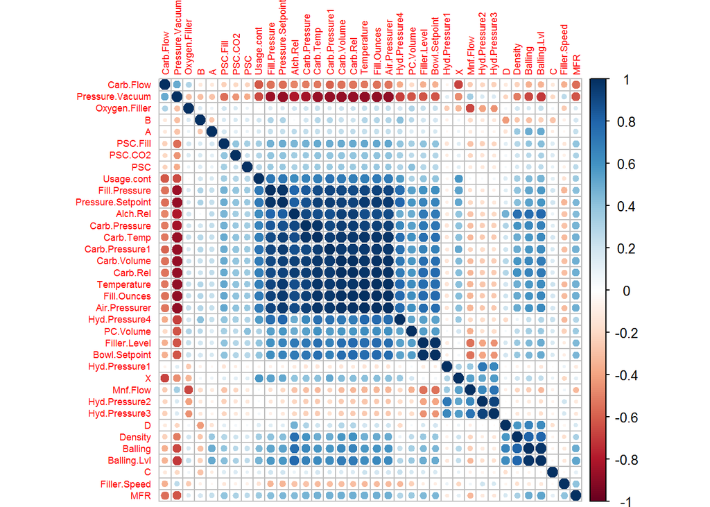

```r
#corrgram(dfModBCSX, order=TRUE,
#         upper.panel=panel.cor, main="Correlation Matrix")
library(corrplot)
#install.packages("corrplot")
correlations <- cor(dfModBCSX)
corrplot(correlations, order = "hclust", tl.cex = 0.55)
```

We can see several very highly correlated variables. We will reduce our dataset and remove pairs that have correlation above 0.75.

```r
hc = findCorrelation(correlations, cutoff=0.75)
length(hc) #18 vars
```

```
## [1] 16
```

```r
#Reducing
dfModBCSRX = dfModBCSX[,-c(hc)] #Box-Cox, Center, Scale
dfPredBCSRX = dfPredBCSX[,-c(hc)]

dfModBRX = dfModBX[,-c(hc)] #Box-Cox
dfPredBRX = dfPredBCSX[,-c(hc)]

dfModSRX = dfModImpSsX[,-c(hc)] #Only Spatial Sign
dfPredSRX = dfPredImpSsX[,-c(hc)]
```

Finallizing data

```r
set.seed(2017)
n75 <- floor(0.75 * nrow(dfBevMod)) #75$ of sample size
n <- sample(seq_len(nrow(dfBevMod)), size = n75)

#Box-Cox, Center, Scale
dfTrainBCSX <- dfModBCSRX[n,]
dfTestBCSX <- dfModBCSRX[-n,]

#Box-Cox
dfTrainBX <- dfModBX[n,]
dfTestBX <- dfModBX[-n,]

#Only Spatial Sign
dfTrainX <- dfModSRX[n,]
dfTestX <- dfModSRX[-n,]

#Response variable
dfTrainY <- dfModImpY[n]
dfTestY <- dfModImpY[-n]
```

At this point data is ready and we can proceed to the modeling step.